# Bridging London

How does the Thames shape cycling connectivity?

Mak Zie / MSc Geographic Data Science / m.b.zie@lse.ac.uk

Explore routes · Key findings · Methods and source code

Geographical proximity does not necessarily mean easy access by bicycle. Using Santander Cycles journey records and modelled bicycle routes, this project explores where the Thames separates observed demand from direct network connectivity, with active travel planning as the motivating application.

715,689

Retained journeys  
March 2026

21.0%

Journeys linking  
opposite banks

1.44×

Median detour  
15 cross-river routes

1.37×

Median detour  
15 same-bank routes

Journey totals describe the full retained dataset; detour estimates describe 30 sampled modelled routes, not all journeys.

## 01 — A network shaped by London’s geography

Of the 801 docking station locations in the November 2026 snapshot, 628 (78.4%) were on the north bank and 173 (21.6%) on the south bank. This distribution describes infrastructure availability, not coverage relative to population or demand.

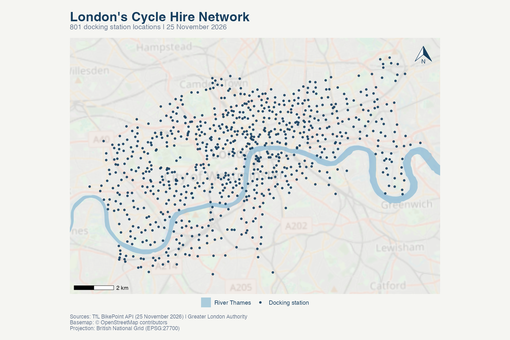

## 02 — Where cross-river cycling demand concentrates

March records contain 73,810 north-to-south and 76,291 south-to-north journeys. The 40 busiest undirected connections account for 3.9% of retained opposite-bank journeys. **Waterloo Station 3, Waterloo** is the leading endpoint within these mapped connections (4,093 journeys). It also ranks first across the full cross-river network.

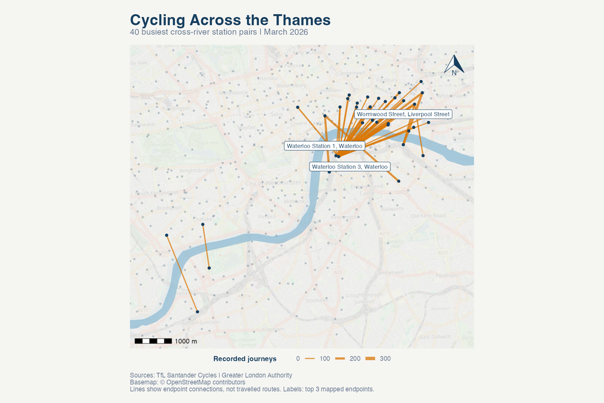

The lines connect observed journey endpoints, not the bridges or paths cyclists used.

## 03 — When geographical proximity is misleading

The two highest-detour routes in the shortest distance band, one per group, illustrate substantial indirectness both across and away from the river.

Case A · Opposite banks

Temple Gardens, Temple → Waterloo Bridge, South Bank

0.73 km direct → 1.50 km by network  
**2.07×** detour ratio

1 recorded journeys in this direction; 1 in both directions combined.

Case B · Same bank

Bonny Street, Camden Town → London Zoo Car Park, The Regent’s Park

0.94 km direct → 1.75 km by network  
**1.86×** detour ratio

4 recorded journeys in this direction; 7 in both directions combined.

These deliberately selected extremes are illustrations, not typical routes or evidence of high-demand investment priorities. The modelled paths deviate up to 392 m and 332 m from their straight-line connections, respectively. The same-bank example shows that river crossings are not necessary for substantial detours; the route geometries alone cannot establish their causes.

Click routes for metrics. Thicker network lines indicate higher detour ratios. To inspect a case, enable its case layer and turn off the two general route layers; dashed lines show direct connections.

[interactive chart not shown]

## 04 — Quantifying the cross-river detour

A detour ratio of 1.44× means the modelled route is 44% longer than the straight-line connection. Cross-river median ratios exceeded same-bank medians in 3 of three distance bands. The largest difference was 0.20 in the 0.5–1 km band.

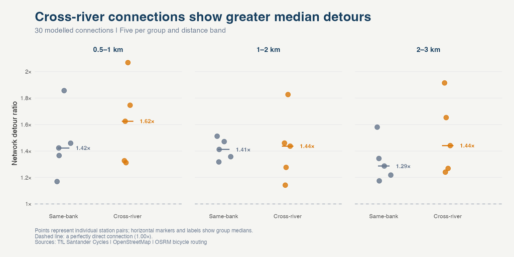

The largest within-band difference in median direct distance was 0.65 km (1–2 km), so the comparison is not perfectly distance-matched. Of classified routes, 15/15 opposite-bank connections crossed once and 0/15 same-bank connections crossed twice or more.

## Implications for active travel

Combining observed journey volumes with modelled detours could help screen connections for closer inspection of cycling infrastructure. The accompanying screening table flags connections above both sample medians for journey count and detour within each distance band; these are candidates for follow-up, not proposed bridge locations. Low recorded demand cannot distinguish limited accessibility from low underlying demand.

## Method and limitations

March 2026 journey records were linked to November station coordinates using TfL terminal identifiers; unmatched, ambiguous and same-station trips were excluded. Subtracting the Thames polygon from a study rectangle defined two banks. A stratified random sample of 30 distinct station pairs was modelled with OSRM’s bicycle profile (one observed direction per pair, five routes per group and distance band).

Small samples, within-band distance imbalance, route snapping and temporal mismatch limit inference. The route audit flags 0 connections for endpoint or ratio review (50 m screening threshold or detour ratio below one). Neither causal effects nor actual cyclist paths can be inferred.

## Data and reproducibility

**Tools:** R, sf, dplyr, ggplot2, ggspatial, ggrepel, leaflet and OSRM.

**Data:** [TfL journey archive](https://cycling.data.tfl.gov.uk/) · [TfL BikePoint API](https://api.tfl.gov.uk/BikePoint) · [GLA River Thames geometry](https://gis.london.gov.uk/arcgis/rest/services/apps/webmap_context_layer/MapServer/1/query?where=1%3D1&outFields=*&returnGeometry=true&outSR=4326&f=geojson) · [OpenStreetMap contributors](https://www.openstreetmap.org/copyright) · [Bicycle routing service](https://routing.openstreetmap.de/).

**Source files:** 01 Data preparation · 02 Spatial analysis · 03 Network analysis.

**Analytical tables:** Station distribution · Directional bank flows · Cross-river station activity · Distance-band comparisons · Sampled demand and detour screening · Route quality audit.

Independent portfolio project developed from GY476 Applied Geographical Information Systems, LSE. Journey period: March 2026; station snapshot and original routing: November 2026. Static maps use British National Grid; the interactive basemap requires internet access. The analytical documents and CSV links require the accompanying project files.